# Practical Machine Learning: Activity Data Classification

Cameron G

September 13, 2017

**Overview**

In this project, we look at data from personal activity devices, such as Jawbone Up, Nike FuelBand, and Fitbit. Six participants performed barbell lifts several ways, generating data from accelerometers on the belt, forearm, arm, and dumbell. The source of the data can be found [here](http://groupware.les.inf.puc-rio.br/har).

This project explores ways to use practical machine learning to predict the types of movement participants engaged in. A model was built using a classification tree, but it was found to have a high estimated out-of-sample error rate. A second model using Random Forest generated a more accurate estimate, with an out-of-sample error rate of 0.1%.

**Loading and Preprocessing Data**

First, we download the data and divide it into training and test sets. The training set is further subdivided into 2 sets for the purpose of building and testing the model. The “testing” set will not be examined until a model has been trained and tested on the “training” set.

```r
#Download the training and testing data
if(!file.exists("pml")){
  dir.create("pml")
}

download.file("https://d396qusza40orc.cloudfront.net/predmachlearn/pml-training.csv",destfile="./pml/pml-training.csv",method="curl")

download.file("https://d396qusza40orc.cloudfront.net/predmachlearn/pml-testing.csv",destfile="./pml/pml-testing.csv",method="curl")

#Load the data into R
library(caret)
training <- read.csv("./pml/pml-training.csv",na.strings=c("NA","#DIV/0!",""))
testing <- read.csv("./pml/pml-testing.csv",na.strings=c("NA","#DIV/0!",""))

set.seed(1234)
inTrain <- createDataPartition(training$classe,p=0.7,list=FALSE)
train_set <- training[inTrain,]
test_set <- training[-inTrain,]
```

Examining the training and test sets, we can see that there are 160 variables in the data, with 13,737 observations in the training set and 5,885 observations in the test set.

```r
dim(train_set)
```

```
## [1] 13737   160
```

```r
dim(test_set)
```

```
## [1] 5885  160
```

Before proceeding with model building, it is a good idea to remove predictors with near zero variance from both the training and test sets. This will eliminate predictors with a particularly low percentage of unique values.

```r
NZV <- nearZeroVar(training,saveMetrics=TRUE)
train_set <- train_set[,NZV$nzv==FALSE]
test_set <- test_set[,NZV$nzv==FALSE]
```

```r
##Remove the first column
train_set <- train_set[,-1]
test_set <- test_set[,-1]

##Remove variables with NA values
train_set <- train_set[,!sapply(train_set,function(x) any(is.na(x)))]
test_set <- test_set[,!sapply(test_set,function(x) any(is.na(x)))]
```

```r
dim(train_set)
```

```
## [1] 13737    58
```

Finally, a quick look at the “classe” variable shows the distribution of the outcome variable we are trying to predict.

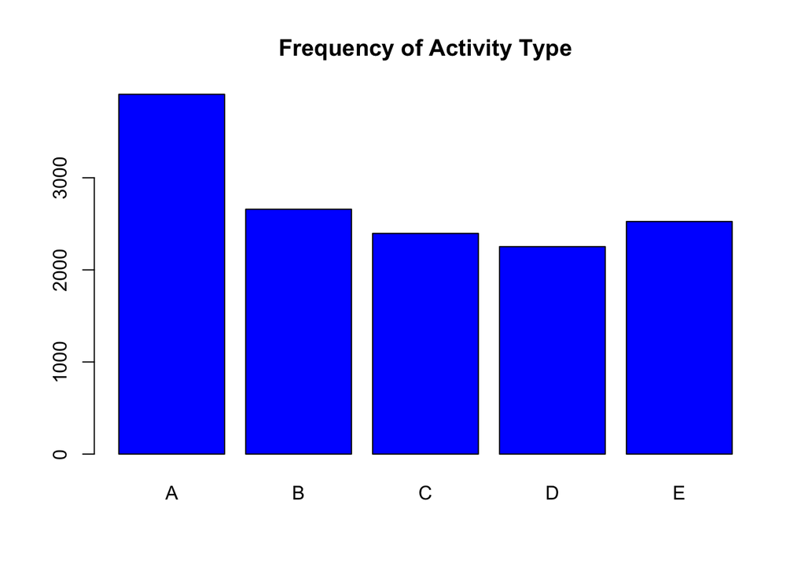

```r
plot(train_set$classe,col="blue",main="Frequency of Activity Type")
```

**Predicting with Trees**

The first model uses a classification tree to divide data into groups based on the split that best separates the “classe” variable.

```r
mod_rpart <- train(classe~.,method="rpart",data=train_set)
print(mod_rpart)
```

```
## CART
##
## 13737 samples
##    57 predictor
##     5 classes: 'A', 'B', 'C', 'D', 'E'
##
## No pre-processing
## Resampling: Bootstrapped (25 reps)
## Summary of sample sizes: 13737, 13737, 13737, 13737, 13737, 13737, ...
## Resampling results across tuning parameters:
##
##   cp          Accuracy   Kappa
##   0.03371987  0.6219929  0.52313561
##   0.03573729  0.5758955  0.45595358
##   0.11738379  0.3340619  0.07502825
##
## Accuracy was used to select the optimal model using  the largest value.
## The final value used for the model was cp = 0.03371987.
```

The resulting tree can be plotted to demonstrate how the model is using values of various predictors to group observations and assign them to a category from A to E.

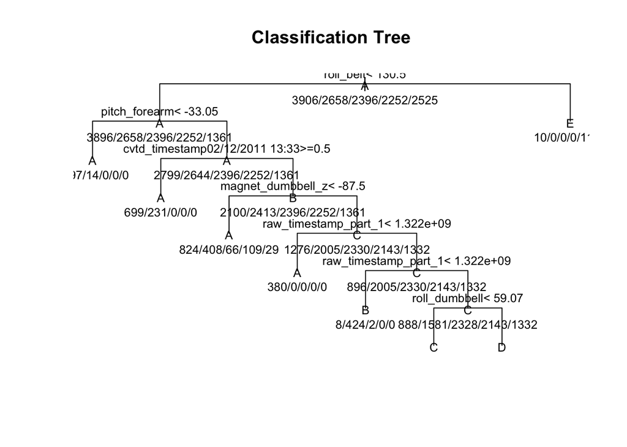

```r
plot(mod_rpart$finalModel,uniform=TRUE,main="Classification Tree")
text(mod_rpart$finalModel,use.n=TRUE,all=TRUE,cex=.8)
```

Once the model is built, we can apply it to the test set.

```r
test_rpart <- predict(mod_rpart,newdata=test_set)
table(test_set$classe,test_rpart)
```

```
##    test_rpart
##        A    B    C    D    E
##   A 1267    2  261  140    4
##   B  290  168  269  412    0
##   C   33    0  864  129    0
##   D   46    0  414  504    0
##   E   19    0  307  289  467
```

**Predicting with Random Forest**

A second model was fitted using the Random Forest method, which generates multiple classification trees and classifies new inputs by tallying “votes” from each tree.

```r
library(randomForest)
mod_rf <- randomForest(classe~.,data=train_set,ntree=500)
mod_rf
```

```
##
## Call:
##  randomForest(formula = classe ~ ., data = train_set, ntree = 500)
##                Type of random forest: classification
##                      Number of trees: 500
## No. of variables tried at each split: 7
##
##         OOB estimate of  error rate: 0.1%
## Confusion matrix:
##      A    B    C    D    E class.error
## A 3906    0    0    0    0 0.000000000
## B    0 2658    0    0    0 0.000000000
## C    0    5 2389    2    0 0.002921536
## D    0    0    3 2248    1 0.001776199
## E    0    0    0    3 2522 0.001188119
```

Cross validation is not necessary for random forests, since error is estimated internally by constructing trees using various bootstrap samples of the original data. The out-of-bag (OOB) error estimate is 0.1%. The Confusion Matrix demonstrates the relatively low error rate using this method.

We can then apply this model to our test set to estimate the out-of-sample error rate.

```r
test_rf <- predict(mod_rf,test_set)
table(test_rf,test_set$classe)
```

```
##
## test_rf    A    B    C    D    E
##       A 1674    2    0    0    0
##       B    0 1137    1    0    0
##       C    0    0 1023    2    0
##       D    0    0    2  962    0
##       E    0    0    0    0 1082
```

Only 7 samples in the test set were misclassified, out of 5,885 samples. In other words, 99% of the samples in the test set were classified correctly.

**Predicting New Values**

Now that we have established a model with an acceptable out-of-sample error rate, we can apply the Random Forest model to predict the class of the new values.

```r
#Subset the testing set to match the variables used in training set
testing <- testing[,which(names(testing) %in% names(train_set))]

#Workaround to avoid error "Type of predictors in new data do not match that of the training data"
train_row <- train_set[1,-58]
testing <- rbind(train_row,testing)
testing <- testing[-1,]

#Predict new values using the model
final.pred <- predict(mod_rf, newdata=testing)
final.pred
```

```
##  1 21  3  4  5  6  7  8  9 10 11 12 13 14 15 16 17 18 19 20
##  B  A  B  A  A  E  D  B  A  A  B  C  B  A  E  E  A  B  B  B
## Levels: A B C D E
```